# `python` Intermediate

### Numerical Analysis with `python`

#### Firsts

## Mauricio Sevilla

`email= j.sevillam@uniandes.edu.co`

08.04.19

We are almost finished with our course!

So now, we are ready to apply all the tools we have developed so far.

This week, we will see how can use code to solve mathematical problems such as,

- Derivate functions.
- Integrate functions (Definited integrals).
- Root searching.

We will use the libraries available on `python` we have worked on last weeks ([NumPy](http://www.numpy.org/) and [Matplotlib](https://matplotlib.org/)).

## Theory

Searching roots of a function is one of the most common problems solved with computers on science. So we are going to learn two of the most widely used methods,

- Bisection
- Newton-Raphson

### Bisection

This method is the simplest when looking for a root<sup>1</sup> of a function $f$ on a given interval $[a,b]$.

1. (Value of $x$ such that $f(x)=0$).

The method work as follows.

1. We select the two points of the interval (the limits).
2. Calculate the middle point.
3. Calculate the function on the midpont.
4. Define the convergence
   1. The interval is small enough.
   2. The value of the function on the midpoint is small enough.
5. If the criteria are not satisfied, check the signs,
   1. If $f(a_n)>0$ and $f(p_n)>0$ or $f(a_n)<0$ and $f(p_n)<0$, then the root is now on $(p_n,b_n]$.
   2. If $f(a_n)<0$ and $f(p_n)>0$ or If $f(a_n)>0$ and $f(p_n)<0$, then the root is now on $(a_n,p_n]$.
6. Repeat for the new limits.

#### Function

[figure not shown]

#### Initial Interval

[figure not shown]

#### Midpoint

[figure not shown]

#### Resize the Interval step 1

[figure not shown]

#### Resize the Interval step 2

[figure not shown]

#### Resize the Interval step 3

[figure not shown]

#### Resize the Interval step 4

[figure not shown]

#### Resize the Interval step 5

[figure not shown]

#### Resize the Interval step 6

[figure not shown]

#### Resize the Interval step 7

[figure not shown]

#### Resize the Interval step 8

[figure not shown]

#### Resize the Interval step 9

[figure not shown]

#### Resize the Interval

[figure not shown]

#### Resize the Interval step 10

[figure not shown]

#### Resize the Interval step 11

[figure not shown]

#### Resize the Interval step 12

[figure not shown]

#### Resize the Interval step 13

[figure not shown]

#### Resize the Interval step 14

[figure not shown]

The first problem we will solve, is finding the value of $x$ such that $f(x)=0$ with

$$ f(x)=\left(\tanh\left(\frac{x}{4}\right)+\frac{\cos(x)\sin(x)}{x}\right)^3 $$

```python
import numpy as np
import matplotlib.pylab as plt
```

```python
def f(x):
    return (np.tanh(0.25*x)+(np.cos(x)*np.sin(x))/x)**3
```

```python
x=np.linspace(-10,10,100)
y=f(x)
```

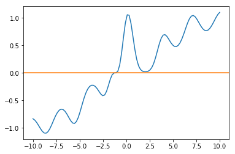

```python
fig=plt.figure()
ax=fig.add_subplot(111)
ax.plot(x,y)
ax.axhline(0,color='C1')
```

```python
def bisec(f,an,bn):
    eps=1e-10
    while (np.abs(an-bn)>eps):
        pm=(an+bn)/2.
        if (f(an)*f(pm)>0):
            an=pm
        else:
            bn=pm
    return pm
```

```python
print(bisec(f,-10,10.1),f(bisec(f,-10,10.1)))
```

```
-1.1908552421034986 1.0627357754887731e-33
```

The first problem we will solve, is finding the value of $x$ such that $f(x)=0$ with

$$ f(x)=\tanh\left(x-2.1\right)+0.1 $$

```python
def f(x0):
    return np.tanh(x0-2.1)+0.1
```

```python
x=np.linspace(-10,10,100)
y=f(x)
```

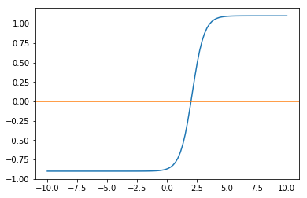

```python
fig=plt.figure()
ax=fig.add_subplot(111)
ax.plot(x,y)
ax.axhline(0,color='C1')
```

```python
print(bisec(f,-10,10.1),f(bisec(f,-10,10.1)))
```

```
1.99966465226571 -3.1823571555733565e-12
```

### Newton

This method is more complex but precise than the bisection. This is also known as the tangent method, because it starts from a guess and moves as the tangent line.

The method work as follows.

We select an initial guess $p_0$, then the following point is found by taking the zero of the derivative on that point. The equation of that line is $$y=f'(p_0)(x_1-x_0)+f(x_0).$$

So, in order to find the value of $x_1$, $y=0$, that leads to $$ x_{i+1}=x_{i}-\frac{f(x_i)}{f'(x_i)}, $$ and it is repeated until a tolerance. (Or $f(x_i)==0$).

#### Function

[figure not shown]

#### Initial Interval

[figure not shown]

#### Midpoint

[figure not shown]

#### Resize the Interval step 1

[figure not shown]

#### Resize the Interval step 2

[figure not shown]

#### Resize the Interval step 3

[figure not shown]

#### Resize the Interval step 4

[figure not shown]

#### Resize the Interval step 5

[figure not shown]

#### Resize the Interval step 6

[figure not shown]

#### Resize the Interval step 7

[figure not shown]

```python
def Newton(f0,df0,xi):
    eps=1e-10
    while np.abs(f0(xi))>eps:
        xi-=f0(xi)/df0(xi)
    return xi
```

Again the first function we are testing

$$ f(x)=\left(\tanh\left(\frac{x}{4}\right)+\frac{\cos(x)\sin(x)}{x}\right)^3 $$

```python
def f(x):
    return (np.tanh(0.25*x)+(np.cos(x)*np.sin(x))/x)**3
```

```python
x=np.linspace(-10,10,100)
y=f(x)
```

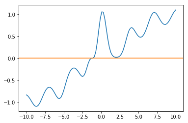

```python
fig=plt.figure()
ax=fig.add_subplot(111)
ax.plot(x,y)
ax.axhline(0,color='C1')
```

```python
def df(x):
    return (0.75/x**4)*((x*np.tanh(0.25*x)+
                         np.sin(x)*np.cos(x))**2.)*(x*x*(np.cosh(0.25*x))**-2.
                                                                      -4*x*np.sin(x)**2+4*x*np.cos(x)**2.-4*np.cos(x)*np.sin(x))
```

```python
print(bisec(f,-10,10.1),Newton(f,df,0.5))
```

```
-1.1908552421034986 -1.1911507242488286
```

```python
def f1(x0):
    return np.tanh(x0-2.1)+0.1
def df1(x0):
    return 1./np.cosh(x0-2.1)**2.
```

```python
x=np.linspace(-10,10,100)
y=f1(x)
```

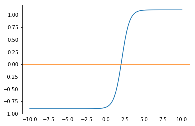

```python
fig=plt.figure()
ax=fig.add_subplot(111)
ax.plot(x,y)
ax.axhline(0,color='C1')
```

```python
print(bisec(f1,-10,10.1),Newton(f1,df1,1.5))
```

```
1.99966465226571 1.9996646522689245
```

But, what if we consider a different initial condition?

```python
print(bisec(f1,-10,10.1),Newton(f1,df1,10.0))
```

```
1.99966465226571 nan
```